# CPBS7602 In-class Regression Examples

Lauren Vanderlinden

Report generated: December 02, 2024

## Simple Linear Regression

**Nut Fungus Example** A drug precursor molecule is extracted from a type of nut. The nuts are commonly contaminated by a fungal toxin that is difficult to remove during the purification process. We suspect that the amount of fungus (and hence toxin) depends on the rainfall at the growing site. We would like to predict toxin concentration from rainfall in order to judge whether it would be worth paying additional rental charges for relatively drier sites. We analyze the toxin content in a series of batches of nuts and we know the rainfall at the growing sites during the four months when the nuts are forming.

**rainfall** is measured in centimeters per week and **toxin** is measured in micrograms per 100 grams of nut.

Toxin Content (microgram per 100 grams) By Amount of Rainfall (cm per week)

| rain | toxin |
| --- | --- |
| 1.30 | 18.1 |
| 2.28 | 28.6 |
| 1.11 | 15.9 |
| 0.74 | 19.2 |
| 1.32 | 19.3 |
| 0.51 | 14.8 |
| 1.56 | 21.7 |
| 1.32 | 16.5 |
| 2.05 | 23.8 |
| 1.37 | 19.0 |

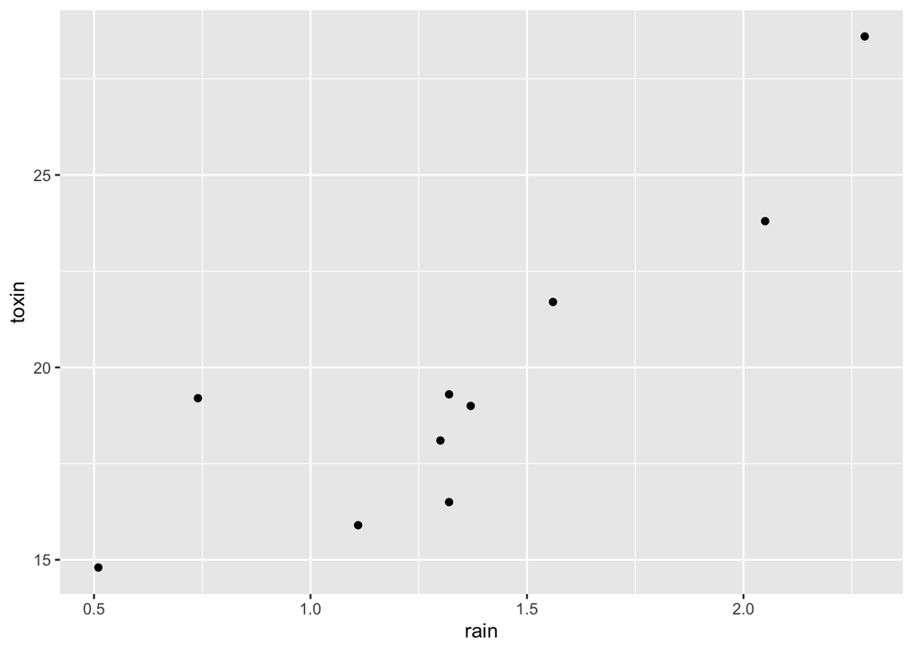

```
##
## Call:
## lm(formula = toxin ~ rain, data = toxin)
##
## Residuals:
##     Min      1Q  Median      3Q     Max
## -2.9479 -1.1061 -0.3528  0.7596  3.6531
##
## Coefficients:
##             Estimate Std. Error t value Pr(>|t|)
## (Intercept)   10.570      1.961   5.390 0.000654 ***
## rain           6.726      1.356   4.961 0.001105 **
## ---
## Signif. codes:  0 '***' 0.001 '**' 0.01 '*' 0.05 '.' 0.1 ' ' 1
##
## Residual standard error: 2.16 on 8 degrees of freedom
## Multiple R-squared:  0.7547, Adjusted R-squared:  0.724
## F-statistic: 24.61 on 1 and 8 DF,  p-value: 0.001105
```

## Multiple Linear Regression

Let’s consider having now 4 potential predictors of concentration of fungal toxin in nuts (μg per 100g). 1. rain - average amount of rainfall in cm per week 2. noon_temp - average temperature (degrees Celsius) at noon 3. sunshine - average number of hours per day of sunshine 4. wind_speed - average wind speed in km per hour

Multiple Predictors of Toxin Content (microgram per 100 grams)

| rain | noon_temp | sunshine | wind_speed | toxin |
| --- | --- | --- | --- | --- |
| 1.30 | 20.9 | 6.23 | 13.3 | 18.1 |
| 2.28 | 25.4 | 8.13 | 10.8 | 28.6 |
| 1.11 | 28.2 | 10.21 | 10.9 | 15.9 |
| 0.74 | 23.7 | 6.96 | 8.2 | 19.2 |
| 1.32 | 26.5 | 9.04 | 9.8 | 19.3 |
| 0.51 | 23.9 | 7.84 | 12.3 | 14.8 |
| 1.56 | 26.7 | 6.69 | 10.0 | 21.7 |
| 1.32 | 30.0 | 8.30 | 12.2 | 16.5 |
| 2.05 | 24.9 | 9.22 | 10.7 | 23.8 |
| 1.37 | 22.0 | 8.37 | 15.0 | 19.0 |

```
##
## Call:
## lm(formula = toxin ~ rain + noon_temp + sunshine + wind_speed,
##     data = toxin)
##
## Residuals:
##       1       2       3       4       5       6       7       8       9      10
## -1.8818  2.0498 -0.6314  0.4787 -0.5805  1.2508 -0.1921 -0.1813 -1.1552  0.8429
##
## Coefficients:
##             Estimate Std. Error t value Pr(>|t|)
## (Intercept)  31.6084     7.1051   4.449  0.00671 **
## rain          7.0676     1.0031   7.046  0.00089 ***
## noon_temp    -0.4201     0.2413  -1.741  0.14215
## sunshine     -0.2375     0.5086  -0.467  0.66018
## wind_speed   -0.7936     0.2977  -2.666  0.04458 *
## ---
## Signif. codes:  0 '***' 0.001 '**' 0.01 '*' 0.05 '.' 0.1 ' ' 1
##
## Residual standard error: 1.574 on 5 degrees of freedom
## Multiple R-squared:  0.9186, Adjusted R-squared:  0.8535
## F-statistic: 14.11 on 4 and 5 DF,  p-value: 0.006232
```

## Multiple Regression with Interaction

Say we have some prior information that the effect of rainfall on toxin levels is dependent on the temperature (as measured at noon time). We would put this into the model as an interaction term between rainfall and the noon temperature.

```
##
## Call:
## lm(formula = toxin ~ rain * temp_binary, data = toxin)
##
## Residuals:
##     Min      1Q  Median      3Q     Max
## -1.7151 -0.9304 -0.1032  0.8287  2.3493
##
## Coefficients:
##                  Estimate Std. Error t value Pr(>|t|)
## (Intercept)        13.380      1.693   7.905 0.000217 ***
## rain                4.690      1.292   3.629 0.010978 *
## temp_binary        -9.731      3.176  -3.064 0.022123 *
## rain:temp_binary    6.345      2.144   2.960 0.025287 *
## ---
## Signif. codes:  0 '***' 0.001 '**' 0.01 '*' 0.05 '.' 0.1 ' ' 1
##
## Residual standard error: 1.556 on 6 degrees of freedom
## Multiple R-squared:  0.9046, Adjusted R-squared:  0.8569
## F-statistic: 18.96 on 3 and 6 DF,  p-value: 0.001831
```

## Logistic Regression

A questionnaire has been used to gather demographics data from some pharmacists, the data include their age and gender.

It also asked ‘Would you personally be happy to provide training in the use of the App? (Yes/No)’

We are concerned with the influence of age on pharmacists’ willingness to train patients in use of a phone App.

10 example observations from study about pharmacists willingness to train patients on device

| Age | Gender | Would_train |
| --- | --- | --- |
| 44 | F | 1 |
| 25 | F | 1 |
| 30 | M | 1 |
| 27 | F | 1 |
| 26 | F | 1 |
| 46 | M | 0 |
| 33 | F | 1 |
| 43 | F | 0 |
| 30 | F | 1 |
| 59 | M | 1 |

```
##
## Call:
## glm(formula = Would_train ~ Age + Gender, family = "binomial",
##     data = willing)
##
## Coefficients:
##             Estimate Std. Error z value Pr(>|z|)
## (Intercept)  4.60567    0.62828   7.331 2.29e-13 ***
## Age         -0.09203    0.01372  -6.706 2.00e-11 ***
## GenderM     -0.01010    0.32196  -0.031    0.975
## ---
## Signif. codes:  0 '***' 0.001 '**' 0.01 '*' 0.05 '.' 0.1 ' ' 1
##
## (Dispersion parameter for binomial family taken to be 1)
##
##     Null deviance: 314.70  on 235  degrees of freedom
## Residual deviance: 249.74  on 233  degrees of freedom
## AIC: 255.74
##
## Number of Fisher Scoring iterations: 4
```

```
##                              2.5 %      97.5 %
## (Intercept) 100.0503976 30.9718057 366.9704989
## Age           0.9120775  0.8866970   0.9358826
## GenderM       0.9899492  0.5289607   1.8762006
```